# Wood flux

# Libraries and data wrangling

```r
knitr::opts_chunk$set(echo = TRUE, cache=TRUE)
library(readr)
library(readxl)
library(randomForest)
library(lubridate)
library(tidyverse)
library(patchwork)
```

## Prepare wood occurrence data

Read and combine files regarding wood pieces.

Wood data = object **Wdata**.

Each line of Wdata corresponds to **a wood piece occurrence**.

```r
# list all files
event_dir <- paste0("data/wood_data/",
                    list.files("data/wood_data/"))
# add variable "event" and create one single tibble with all events
my_read=function(file){
  if(stringr::str_sub(file,-5)==".xlsx"){
    result=readxl::read_excel(file) %>%
      select(Time)}
  if(stringr::str_sub(file,-4)==".txt"){
    result=readr::read_table2(file,skip=1) %>%
      mutate(Time=paste0(lubridate::dmy(Date)," ", as.character(Time))) %>%
      mutate(Time=lubridate::ymd_hms(Time)) %>%
      select(Time)
  }
  return(result)
}
Wdata=tibble(event= paste0("event_",1:length(event_dir)),
             event_dir=event_dir,
             provider=c(rep("Bruce",3), rep("Zhang",4)),
             wood_file=event_dir %>% map(list.files)) %>%
  unnest() %>%
  mutate(wood_file=paste0(event_dir,"/",wood_file)) %>%
  mutate(data= map(wood_file,my_read))%>%
  unnest() %>%
  select(-event_dir) %>%
  mutate(Day=date(Time))
```

$W$: waiting time between two consecutive wood pieces

```r
Wdata <- Wdata %>%
  arrange(Time) %>%
  mutate(Thour=floor_date(Time,unit="hour")) %>%
  mutate(W=difftime(Time,lag(Time,1), units="secs") %>% as.numeric())%>%
  group_by(Time) %>%
  mutate(npieces=n()) %>%
  ungroup() %>%
  mutate(W=case_when(npieces<=1~W,
                     npieces>1~1/npieces)) %>%
  mutate(Wpb=case_when(
    W >= (10*60*60) & provider=="Zhang" ~ 1,     # more than 10h
    W <  (10*60*60) & provider=="Zhang" ~ 0,    # less than 10h
    W >= (20*60) & provider=="Bruce" ~ 1,    # more than 20 minutes for Bruce's data
    W < (20*60) & provider=="Bruce" ~ 0)) %>%
  filter(Wpb==0) %>%
  # Very low waiting times actually correspond to
  # the limitation in time resolution.
  mutate(Y=log(3600/W)) %>%
  na.omit()
```

$Y=ln(\frac{3600}{W})$

Multiplying by 3600 makes $\frac{3600}{W}$ have a dimension $hour{^-1}$.

## Prepare discharge data

Discharge data = object **Qdata** and file **Qdata.csv**.

Each line of this table corresponds to **a point in time** for which discharge was measured. Contrary to Wdata, each of these lines does not necessarily correspond to a registered occurrence of wood.

To build Qdata, I downloaded QTVAR datafiles (with precision 1%) from **banque hydro**, ranging from 01/01/2000 to 31/12/2013.

I calculated the variable $T_Q$ at time t, which corresponds to **the time elapsed since last time Q was at the same value as observed at t**.

I also calculated the variable $S$ which corresponds to the **difference in discharge on a small timelag (5 minutes)**.

$$S=Q_{time}-Q_{time-5min}$$

```r
if(!file.exists("data/Qdata.csv")){
    Qfiles=paste0("data/discharge_data/qtvar",2000:2013,".csv")
    # We're going to calculate Qdata, the datatable related to discharge:
    Qdata=Qfiles %>%
      # Read all discharge files (yearly files):
      map(~read_delim(.,
                      ";",
                      escape_double = FALSE,
                      trim_ws = TRUE,
                      skip = 10,
                      locale = locale(decimal_mark = ",",
                                      encoding = "ISO-8859-1"))) %>%
      # bind them together:
      bind_rows() %>%
      # change names of variables to Time and Q:
      select(Time=Date,
             Q=`Q (m3/s)`) %>%
      # define how Time is formatted:
      mutate(Time=dmy_hm(Time)) %>%
      # create void variable T_Q:
      mutate(T_Q=NA)
    # We're going to fill T_Q through a loop
    # For any point in time (i-th row of Qdata)
    for (i in 10000:nrow(Qdata)){
      # myQ is current value of Q.
      myQ=Qdata$Q[i]
      # For all previous points in time,
      s=sign(myQ-Qdata$Q[1:(i-1)])
      # which are the ones that correspond to a higher discharge?
      ind=which(s<0)
      # And which of these is the latest one?
      ind=ind[length(ind)]
      # Let's consider this point in time and the one right afterwards
      ind=ind:(ind+1)
      # If there's a difference in discharge between these two points
      if(diff(Qdata$Q[ind])!=0){
        # then we're gonna interpolate the exact time when:
        # Q was exactly equal to myQ
        time=as.POSIXct(approx(x=Qdata$Q[ind],
                               y=as.numeric(Qdata$Time[ind],
                                            origin="1970-01-01 00:00:00"),
                               xout=myQ)$y,
                        origin="1970-01-01 00:00:00")
      }else{
        # else we just take that first point in time
        time=mean(Qdata$Time[ind])
      }
      Qdata$T_Q[i]=difftime(Qdata$Time[i],time,units="days")
      # T_Q at point i in time is equal to the difference (in days) between
      # a) time at point i and b) time when such a discharge was last seen
    }
    #######
    # Remove the first lines of discharge data, for which we don't
    # go back enough in time to calculate T_Q
    Qdata <- na.omit(Qdata)
    Qdata <- Qdata %>%
      mutate(Time=ymd_hms(Time),
             S=Q-approx(Qdata$Time,Qdata$Q,xout=Qdata$Time-60*5)$y)
    # S is the difference between Q(time i) and Q(time i-5 minutes)
    readr::write_csv(Qdata, "data/Qdata.csv")
}

# Read Qdata and keep only relevant days
Qdata=readr::read_csv("data/Qdata.csv") %>%
  mutate(Day=date(Time)) %>%
  left_join(select(Wdata, Day, event) %>% unique(),by="Day") %>%
  na.omit()
# Interpolate Qdata to have Q, T_Q, S every hour of the events
Qdata=tibble(Time=seq(floor_date(min(Qdata$Time), unit="hour"),
                      ceiling_date(max(Qdata$Time), unit="hour"),
                      by="1 hour")) %>%
   mutate(Day=date(Time)) %>%
   left_join(select(Wdata, Day, event) %>% unique(),by="Day") %>%
   mutate(Q=approx(Qdata$Time,Qdata$Q,xout=Time)$y,
          T_Q=approx(Qdata$Time,Qdata$T_Q,xout=Time)$y,
          S=approx(Qdata$Time,Qdata$S,xout=Time)$y) %>%
   mutate(rT_Q=sqrt(T_Q)) %>%
   na.omit()
```

Qdata hence contains the variables

- Q
- S
- T_Q
- rT_Q ($\sqrt {T_Q}$)

These are interpolated to obtain **discharge data every hour** of the events.

## Complete wood occurrence data with discharge descriptors

**Discharge data (variables Q, S, T_Q, rT_Q) is joined to wood occurrence data (Wdata)**:

```r
Wdata <- Wdata %>%
  mutate(Q=approx(Qdata$Time,Qdata$Q,xout=Wdata$Time)$y,
         T_Q=approx(Qdata$Time,Qdata$T_Q,xout=Wdata$Time)$y,
         S=Q-approx(Qdata$Time,Qdata$Q,xout=Wdata$Time-5*60)$y) %>%
  filter(!is.na(Time))%>%
  mutate(rT_Q=sqrt(T_Q))
```

## Prepare graphics and calculations

```r
events=unique(Wdata$event)
NightTime=tibble(event=Wdata$event,
                 Day=Wdata$Day) %>%
  unique() %>%
  mutate(night=ymd_hms(paste0(Day-days(1)," 18:00:00")),
         day  =ymd_hms(paste0(Day," 6:00:00")))
```

We pre-define **breaks and labels for logarithmic axes**:

```r
labels=c(1,rep("",8),
        10,rep("",8),
        100,rep("",8),
        1000,rep("",8),
        10000,rep("",9))
breaks=c(seq(1,10,by=1),
        seq(20,100,by=10),
        seq(200,1000,by=100),
        seq(2000,10000,by=1000),
        seq(20000,100000,by=10000))
```

# RandomForest: Y as a function of Q, S, rT_Q

## Fitting of the Random Forest

Fit of a random forest with **Y** as response and predictors **Q**, **rT_Q** and **S**.

```r
set.seed(33)
Wdata_rf <- Wdata %>%
    select(Q,
           rT_Q,
           S,
           Y) %>%
    na.omit()
myrf=randomForest(Y~., data=Wdata_rf)
myrf
```

```
##
## Call:
##  randomForest(formula = Y ~ ., data = Wdata_rf)
##                Type of random forest: regression
##                      Number of trees: 500
## No. of variables tried at each split: 1
##
##           Mean of squared residuals: 1.623473
##                     % Var explained: 49.48
```

## Cross-validation

```r
set.seed(33)
Wdata_cv=Wdata %>%
  mutate(part=ifelse(runif(nrow(Wdata))>=0.8,"test","train"))
xtest=Wdata_cv %>% filter(part=="test") %>% select(Q,rT_Q,S) %>% as.data.frame()
ytest=Wdata_cv %>% filter(part=="test") %>% select(Y) %>% pull()
Wdata_cv <- Wdata_cv %>%
    select(Q,
           rT_Q,
           S,
           Y) %>%
    na.omit()
rf_cv=randomForest(Y~., data=Wdata_cv, xtest=xtest,ytest=ytest)
rf_cv
```

```
##
## Call:
##  randomForest(formula = Y ~ ., data = Wdata_cv, xtest = xtest,      ytest = ytest)
##                Type of random forest: regression
##                      Number of trees: 500
## No. of variables tried at each split: 1
##
##           Mean of squared residuals: 1.621765
##                     % Var explained: 49.53
##                        Test set MSE: 0.99
##                     % Var explained: 69.77
```

The random forest converges rapidly (so that the default value of 500 trees is enough):

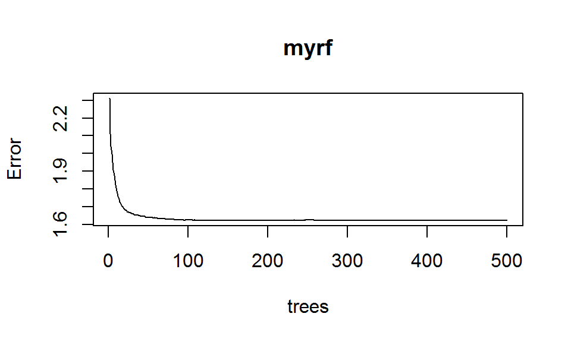

```r
plot(myrf)
```

## Variables importance and effect

Relative importance of predictors in the prediction of response:

```r
impdat=importance(myrf) %>%
  as.data.frame() %>%
  tibble::rownames_to_column() %>%
  arrange(desc(IncNodePurity)) %>%
  mutate(prop=paste0(round(IncNodePurity/sum(IncNodePurity),2)*100,"%"))
impdat
```

```
##   rowname IncNodePurity prop
## 1    rT_Q      20992.59  41%
## 2       Q      16578.81  32%
## 3       S      13577.73  27%
```

Result of calls to function partialPlot: depicts marginal effect of a variable on response. Reference: Friedman, J. (2001). Greedy function approximation: the gradient boosting machine, Ann. of Stat.

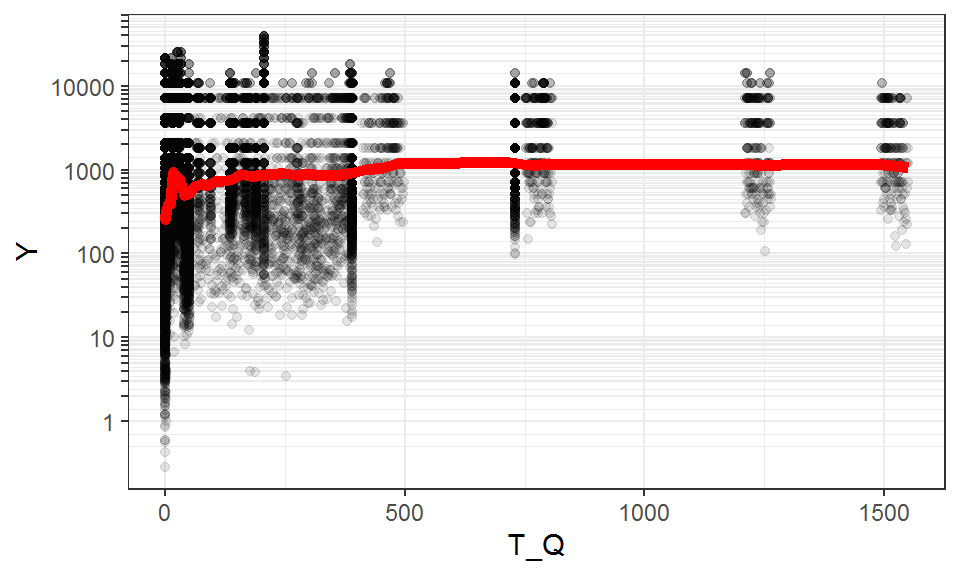

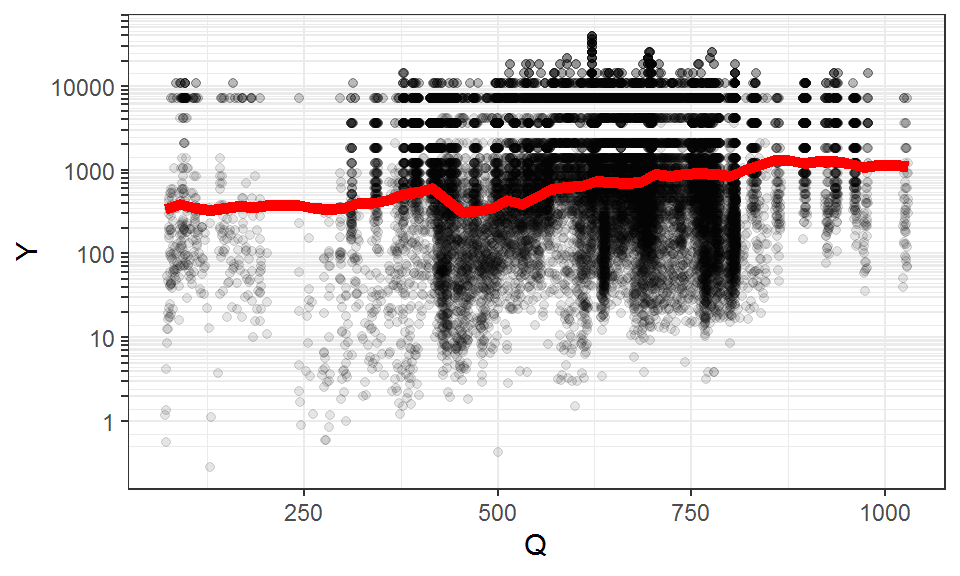

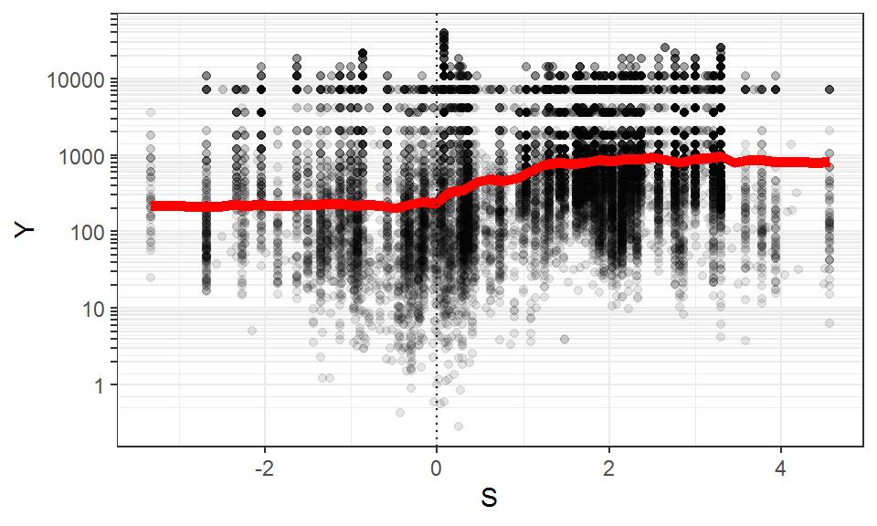

```r
pdata=vector(length=3,mode="list")
for (i in 1:3){
  varname=impdat$rowname[i]
  pdata[[i]]=partialPlot(myrf,
                    pred.data=as.data.frame(Wdata %>%
                                              select(rT_Q,Q,S)),
                    impdat$rowname[i],
                    plot=FALSE) %>%
    as_tibble()
  if(varname=="rT_Q"){
    pdata[[i]]=mutate(pdata[[i]],x=x^2)
  }
}

varnames = c("T_Q","Q","S")
for (i in 1:3){
  Wp=Wdata %>% mutate_(x=varnames[i]) %>% mutate(y=exp(Y))
  p=ggplot(Wp,
           aes(x=x,y=y))+
    geom_point(alpha=0.1)+
    geom_line(data=pdata[[i]],aes(x=x,y=exp(y)), col="red", lwd=2)+
    xlab(varnames[i])+
    ylab("Y")+
    scale_y_continuous(trans="log",
                       breaks=breaks,
                       labels=labels)+
    theme_bw()
  if(varnames[i]=="S"){p=p+geom_vline(xintercept=0,linetype=3)}
  print(p)
}
```

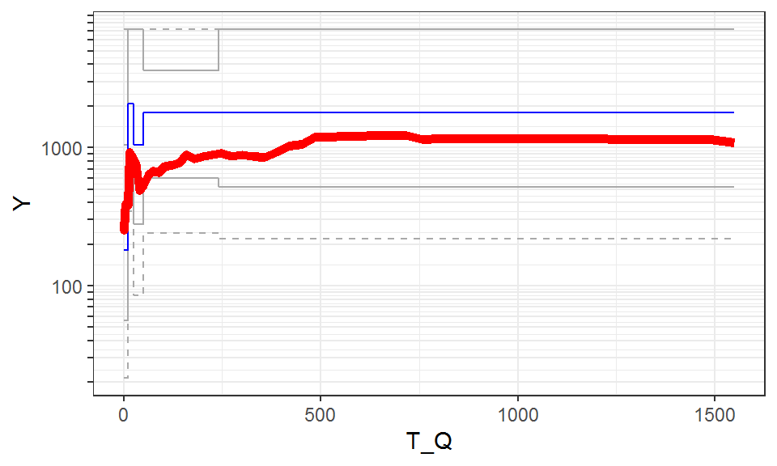

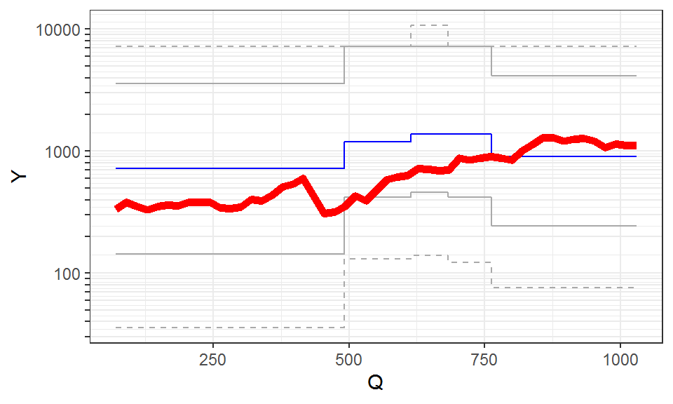

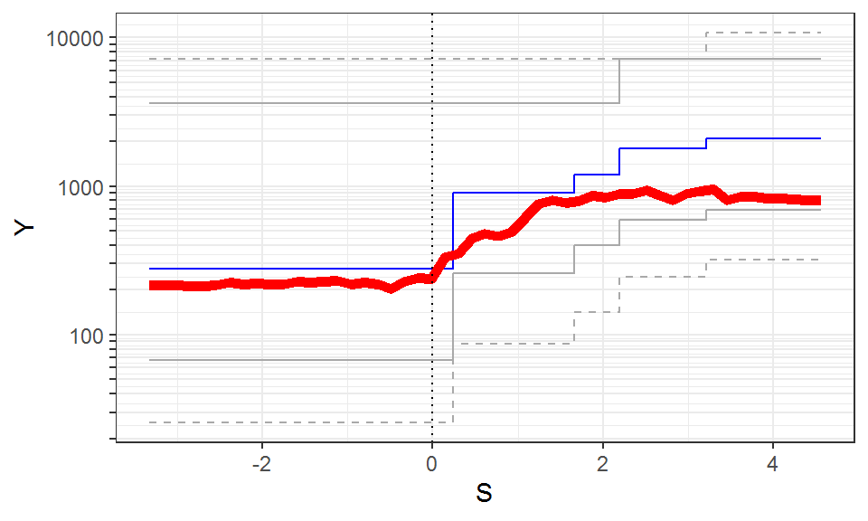

```r
varnames = c("T_Q","Q","S")
for (i in 1:3){
  Wp=Wdata %>%
    mutate_(x=varnames[i]) %>%
    mutate(y=exp(Y))
  if(i==1){Wp=Wp %>%
    mutate(x=sqrt(x))}
  tibq=tibble(q=unique(quantile(Wp$x,
                                seq(0,1,by=0.2)))) %>%
    mutate(x1=q,
           x2=lead(q,1)) %>%
    mutate(qid=rank(q,ties.method="first"))
  tibql=tibq %>%
    na.omit() %>%
    tidyr::pivot_longer(cols=starts_with("x"))
  Wpsum=Wp %>%
    mutate(qid=as.numeric(cut(x,tibq$q,
                 include.lowest=TRUE))) %>%
    group_by(qid) %>%
    summarise(y0.1=quantile(y,0.1),
              y0.25=quantile(y,0.25),
              y0.5=quantile(y,0.5),
              y0.75=quantile(y,0.75),
              y0.9=quantile(y,0.9)) %>%
    ungroup() %>%
    left_join(tibql, by="qid") %>%
    mutate(x=value)
  if(i==1){Wpsum=Wpsum %>%
    mutate(x=x^2)}
  p=ggplot(Wp,
           aes(x=x,y=y))+
    geom_line(data=Wpsum, aes(x=x,y=y0.1),col="dark grey", linetype=2)+
    geom_line(data=Wpsum, aes(x=x,y=y0.9),col="dark grey", linetype=2)+
    geom_line(data=Wpsum, aes(x=x,y=y0.25),col="dark grey")+
    geom_line(data=Wpsum, aes(x=x,y=y0.75),col="dark grey")+
    geom_line(data=Wpsum, aes(x=x,y=y0.5),col="blue")+
    geom_line(data=pdata[[i]],aes(x=x,y=exp(y)), col="red", lwd=2)+
    xlab(varnames[i])+
    ylab("Y")+
    scale_y_continuous(trans="log",
                       breaks=breaks,
                       labels=labels)+
    theme_bw()
  if(varnames[i]=="S"){p=p+geom_vline(xintercept=0,linetype=3)}
  print(p)
}
```

## Get predictions of the Random Forest

Predict values for Wdata and Qdata.

```r
Wdata <- Wdata %>%
  mutate(Ypred=predict(myrf,.))
Qdata <- Qdata %>%
  mutate(Ypred=predict(myrf,.))
```

## Plot of Predictions & Observations = f(time)

Here we plot vs time:

- **observations** (in green)
- **predictions** (in red, solid line)

### Raw observations

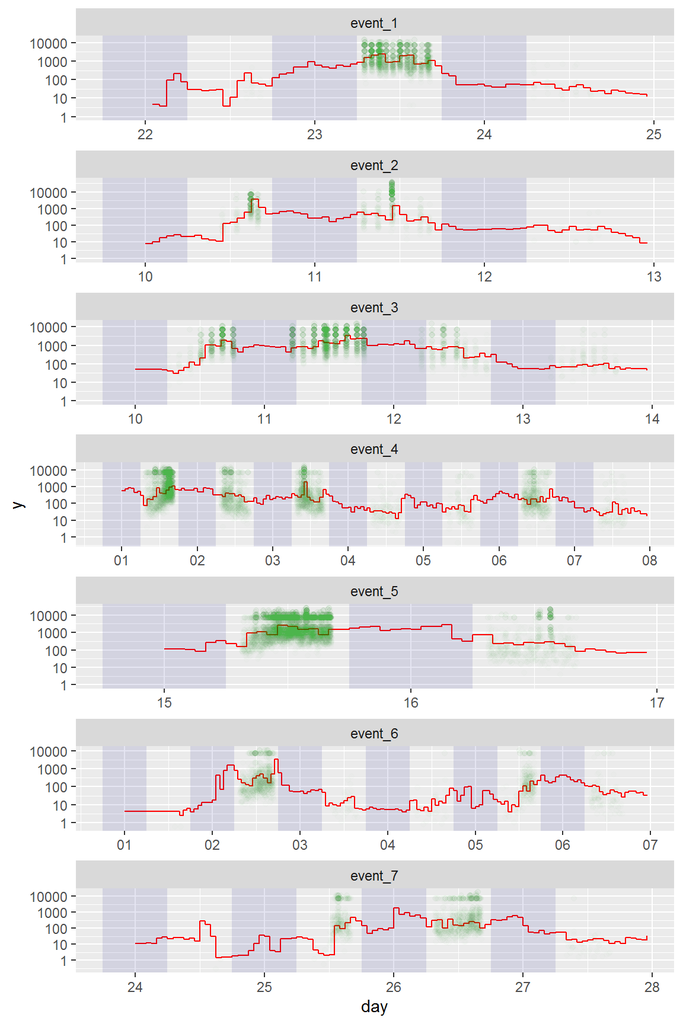

```r
ggplot(NightTime, aes(x=day,y=1))+
 # prediction: red line
 geom_step(data=Qdata,aes(x=Time, y=exp(Ypred)),color="red")+
 geom_point(data=Wdata,
            aes(x=Time, y=exp(Y)),
            color="forestgreen",alpha=0.01)+
 facet_wrap(~event, scale="free", nrow=length(events))+
 geom_rect(aes(xmin=night,xmax=day,ymin=0,ymax=+Inf),
            fill="navy",alpha=0.1)+
 scale_y_log10()+
 scale_x_datetime(date_labels =  "%d", date_breaks="1 day")
```

### Hourly summaries of observations and predictions=f(time)

Here we **summarise the data by hour**, and show the wood flux per hour (number of wood pieces per hour):

- predicted value $n_{pred}$ (in red)
- observed value $n_{obs}$.

Both values are **corrected** to take into account the **actual observation time per hour**.

```r
Wdatasum=Wdata %>%
      mutate(Time=Thour) %>%
      group_by(event, Day, Time) %>%
      summarise(Nraw=n(),
                sW=sum(W))%>%
      mutate(N=Nraw*(3600/sW)) %>%
      ungroup() %>%
      na.omit() %>%
      ungroup()
```

We have modelled $Y=log(\frac{3600}{W})$.

Considering that $Y$ has a roughly symetrical distribution, we can consider that :

$median(Y)=mean(Y)$

Hence $median(W)=\frac{3600}{exp(median(Y))}$

Considering that W is a waiting time without memory process we can consider that it follows an exponential distribution. Hence

$mean(W)=\frac{median(W)}{ln(2)}$

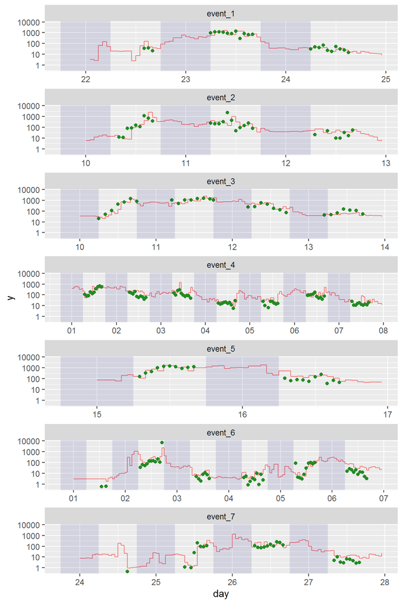

```r
Qdata=Qdata %>%
    mutate(Wpred=3600/exp(Ypred)) %>%
    mutate(Wpred=Wpred/log(2)) %>%
    mutate(Npred=3600/Wpred) %>%
  left_join(Wdatasum %>% select(Time,N),by="Time") %>%
    mutate(Y=log(N))
ggplot(NightTime, aes(x=day,y=1))+
  # prediction: red line
  geom_step(data=Qdata,stat="identity",aes(x=Time, y=Npred),fill="red", alpha=0.5, col="red")+
  scale_y_continuous(trans="log")+
  facet_wrap(event~., scales="free_x",nrow=length(events))+
  geom_point(data=Wdatasum,aes(x=Time,y=N), col="forestgreen")+
  geom_rect(aes(xmin=night,xmax=day,ymin=0,ymax=+Inf),
            fill="navy",alpha=0.1)+
  scale_y_log10()+
  scale_x_datetime(date_labels =  "%d", date_breaks="1 day")
```